#### 02.05.23, © Dmitro Akhinian, 2023

# Лабораторна робота №9. Рядки. Методи рядків і списків. Винятки. Частина ІІ

**Мета:** *навчитися обробляти рядки за допомогою спеціальних функцій і методів.*

## Основні методи та функції для обробки рядків

### Основні методи для обробки рядків

- `capitalize()` – замінює всі мали букви на великі;
- `center()` – центрує рядок всередині поля відомої довжини;
- `count()` – рахує кількість входжень даного символу в рядку;
- `join()` – з'єднує всі елементи кортежу/списку в один рядок;
- `lower()` – перетворює всі літери рядка на малі;
- `lstrip()` – видаляє білі символи з початку рядка;
- `replace()` – замінює задану підрядок іншим;
- `rfind()` – знаходить підрядок, пошук починається з кінця рядка;
- `rstrip()` – видаляє білі символи з кінця рядка;
- `split()` – розбиває рядок на підрядки з використанням заданого роздільника;
- `strip()` – видаляє білі символи з початку і кінця рядка;
- `swapcase()` – змінює регістр літер на протилежний (малі на великі і навпаки);
- `title()` – робить першу літеру в кожному слові великою;
- `upper()` – перетворює всі літери рядка на великі.

### Аналіз вмісту рядків

Содержимое строки можна визначити за допомогою наступних методів (вони повертають логічні значення):

- `endswith()` - закінчується рядок заданою підстрокою?
- `isalnum()` - складається рядок лише з букв і цифр?
- `isalpha()` - складається рядок лише з букв?
- `islower()` - складається рядок лише з малих літер?
- `isspace()` - складається рядок лише з пробільних символів?
- `isupper()` - складається рядок лише з великих літер?
- `startswith()` - починається рядок з даної підстроки?

### Приклад 1

Ви знаєте, що таке паліндром?

Це слово, яке виглядає однаково під час читання вперед і назад. Наприклад, "козак" - це паліндром, а "лояльний" - ні.

Ваше завдання - написати програму, яка:

- запитує у користувача текст;
- перевіряє, чи є введений текст паліндромом, і друкує результат.

Примітка:

- припустимо, що порожній рядок не є паліндромом;
- великі та малі літери обробляються як однакові;
- прогалини не враховуються під час перевірки - розглядайте їх як неіснуючі;
- правильних рішень більш ніж кілька – спробуйте знайти більше одного.

Протестуйте свій код, використовуючи надані нами дані.

Приклад вводу:

`А роза упала на лапу Азора`

Приклад виводу:

`It's a palindrome`

```python
def ispalindrom(text):
    text = text.replace(" ", "").lower()
    if text == text[::-1]:
        print("It's a palindrom")
    else:
        print("It's not a palindrom")

text = input("Введіть текст:")
ispalindrom(text)

text = input("Введіть текст:")
ispalindrom(text)
```

```
It's a palindrom
```

```
It's not a palindrom
```

### Приклад 2

Анаграма -- це нове слово, сформоване шляхом перестановки букв слова, використовуючи всі оригінальні букви рівно один раз. Наприклад, слова "Актёр" та "тёрка" є анаграмами, а "я є" і "ви є" -- ні.

Ваше завдання -- написати програму, яка:

- запитує у користувача два окремі тексти;
- перевіряє, чи введені тексти є анаграмами, і виводить результат.

Примітка:

- припустимо, що два порожні рядки не є анаграмами;
- великі та малі літери обробляються як однакові;
- прогалини не враховуються під час перевірки - трактуйте їх як неіснуючі.

Протестуйте свій код, використовуючи надані нами дані.

Приклад вводу:

`Listen`  
`Silent`

Приклад виводу:

`Anagrams`

Приклад вводу:

`modern`  
`norman`

Приклад вивода:

`Not anagrams`

```python
# Пеервірка на анаграму

text1 = input("Введіть перше слово:")
text2 = input("Введіть друге слово:")

text1 = list(text1.replace(" ", "").lower())
text2 = list(text2.replace(" ", "").lower())

if sorted(text1) == sorted(text2):
    print("Анаграми")
else:
    print("Не анаграми")
```

```
Анаграми
```

### Приклад 3

Дехто каже, що Цифра життя – це цифра, обчислена з використанням чийогось дня народження. Все просто – потрібно просто скласти всі цифри дати. Якщо результат містить більше однієї цифри, Ви повинні повторювати додавання, доки не отримаєте одну цифру. Наприклад:

1 January 2017 = 2017 01 01 2 + 0 + 1 + 7 + 0 + 1 + 0 + 1 = 12 1 + 2 = 3 3 - цифра, яку ми шукали та знайшли.

Ваше завдання - написати програму, яка:

запитує користувача про його/її день народження (у форматі РРРГММДД, або РРРРДДММ, або ММДДРРРР - фактично порядок цифр не має значення); виводить цифру життя для дати. Протестуйте свій код, використовуючи надані нами дані.

Тестові дані:

`19991229`  
`6`

Приклад вивода:

`20000101` `4`

```python
# ПЕРШИЙ варіант

# Обчислює число "життя": суму цифр повної дати народження
date = input("Введіть дату народження у форматі YYYYMMDD:")

while True:
    sum = 0
    for simbol in date:
        sum += int(simbol)

    date = str(sum)

    if len(date) == 1:
        break

print(sum)
```

```
6
```

```python
# ДРУГИЙ варіант

# def calculate_life_number(date):
#     # видалення всіх символів, окрім цифрр
#     digits = ''.join(filter(str.isdigit, date))

#     # вычисление суммы цифр
#     digit_sum = sum(int(d) for d in digits)

#     # повторне додавання, якщо результат містить більше однієї цифри
#     while digit_sum > 9:
#         digit_sum = sum(int(d) for d in str(digit_sum))

#     return digit_sum


# # Запит дати народження користувача
# date = input("Введіть дату народження у форматі РРРРММДД, РРРРДДММ или ММДДРРРР: ")

# # Обчислення цифри життя та виведення результату
# life_number = calculate_life_number(date)
# print("Цифра життя для дати {}: {}".format(date, life_number))
```

### Завдання 1

Давайте зіграємо у гру. Ми дамо Вам два рядки: один - слово (наприклад, "dog"), а другий - комбінація будь-яких символів.

Ваше завдання – написати програму, яка відповість на наступне запитання: символи, що становлять перший рядок, приховані всередині другого рядка?

Наприклад:

якщо другий рядок заданий як "vcxzxduybfdsobywuefgas", відповідь `Yes`; якщо другий рядок "vcxzxdcybfdstbywuefsas", відповідь `No` (бо немає букв "d", "o" або "g" у цьому порядку).

Підказка:

Ви повинні використовувати варіанти з двома аргументами функцій `find()` всередині коду; не турбуйтеся про чутливість до регістру. Протестуйте свій код, використовуючи надані нами дані.

```python
wrd = input("Input word:")
comb = input("Input combination:")
n = 0
found_flag = True

for let in wrd:
    n = comb.find(let, n) + 1
    if n == 0:
        found_flag = False
        break
if found_flag:
    print("Word is found")
else:
    print("Word is not found")
```

```
Input word:dog
Input combination:vcxzxduybfdsobywuefgas
Word is found
```

## Обробка винятків

### Приклад 4

Можна "ловити" і обробляти винятки в Python за допомогою `try-except` блоку. Отже, якщо у є підозра, що будь-який конкретний шматок коду може викликати виняток, можна написати код, який коректно оброблятиме його і не припинить виконання програми:

```python
while True:
    try:
        number = int(input(" Введіть ціле число: "))
        print(number/2)
        break
    except:
        print("Введене значення не є допустимим числом. Повторіть спробу...")
```

```
Введене значення не є допустимим числом. Повторіть спробу...
```

```
6.0
```

### Завдання 4

Модифікувати код з **Прикладу 3** таким чином, щоби виняток, який виникає при введені, оброблявся і забезпечував функціонування програми.

```python
while True:
    try:
        date = input("Введіть дату народження у форматі YYYYMMDD:")

        if len(date) != 8 or not date.isnumeric():
            raise SyntaxError
        break
    except SyntaxError:
        print("Некоректне введення, спробуйте ще раз")


while True:
    sum = 0
    for simbol in date:
        sum += int(simbol)

    date = str(sum)

    if len(date) == 1:
        break

print(sum)
```

```
Введіть дату народження у форматі YYYYMMDD:a0667957
Некоректне введення, спробуйте ще раз
Введіть дату народження у форматі YYYYMMDD:999999999999
Некоректне введення, спробуйте ще раз
Введіть дату народження у форматі YYYYMMDD:20021110
7
```

### Приклад 4

Ваше завдання - написати функцію, здатну набувати цілочисельних значень і перевіряти, чи знаходяться вони в зазначеному діапазоні.

Функція повинна:

- прийняти три аргументи: запит на введення даних, допустимі верхній та нижній межі;
- якщо користувач вводить рядок, який не є цілим числом, функція повинна видати повідомлення `Error: wrong input і попросити користувача ввести значення знову`;
- якщо користувач вводить число, яке виходить за межі вказаного діапазону, функція повинна видати повідомлення Error: the value is not within permitted range (`min..max`) і попросити користувача знову ввести значення;
- якщо вхідне значення допустиме, поверніть його як результат.

```python
def fun(number, lower, upper):
    while True:
        try:
            if int(number) < lower or int(number) > upper:
                raise ArithmeticError
            return number
        except ValueError:
            print("Error: wrong input")
            number = input("Input another value for number:")
        except ArithmeticError:
            print("Error: the value is not within permitted range (min..max)")
            number = input("Input another value for number:")


print(fun("a", 10, 30))
```

```
Error: wrong input
Input another value for number:40
Error: the value is not within permitted range (min..max)
Input another value for number:15
15
```

### Контрольні запитання

1. Який очікуваний вивід наступного коду?

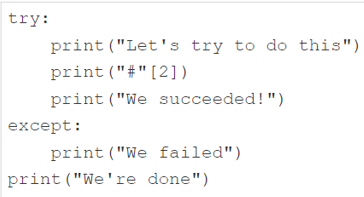

1. Який очікуваний результат наступного коду?

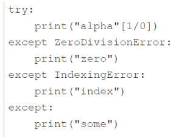

### Відповіді на контрольні запитання

1. Let's try to do this  
   We failed  
   We're done
2. zero